# Experimental treatment with edaravone in a mouse model of spinocerebellar ataxia 1

PSA-NCAM immunofluorescence intensity in hippocampus

Author

Martina Sucha, Simona Benediktova, Filip Tichanek, Jan Jedlicka, Stepan Kapl, Dana Jelinkova, Zdenka Purkartova, Jan Tuma, Jitka Kuncova, Jan Cendelin

This page shows R code for the study [Sucha et al.](https://www.mdpi.com/1422-0067/24/13/10689) (2023, *International Journal of Molecular Science*).

**Citation**:

> Sucha M, Benediktova S, Tichanek F, Jedlicka J, Kapl S, Jelinkova D, Purkartova Z, Tuma J, Kuncova J, Cendelin J. Experimental Treatment with Edaravone in a Mouse Model of Spinocerebellar Ataxia 1. International Journal of Molecular Sciences. 2023; 24(13):10689. https://doi.org/10.3390/ijms241310689

[GitHub page](https://github.com/filip-tichanek/edaravonSCA1): https://github.com/filip-tichanek/edaravonSCA1

PSA-NCAM immunofluorescent intensity was measured in 4 part of hippocampus. The most important is *Cornu Ammonis - stratum laconosum-moleculare* (*CA-SRLM*), where our previous study found difference between SCA1 and WT genotype. Model specification will be thus done for the *CA-SRLM* and the same specification will be done also for other 3 hippocampal subregions.

# 1 Upload of packages

```r
rm(list = ls())

suppressWarnings(suppressMessages( {
library(brms)
library(beeswarm)
library(vioplot)
library(glmmTMB)
library(car)
library(cowplot)
library(ggplot2)
library(tidyverse)
library(bayesplot)
library(gtsummary)
library(vegan)
library(knitr)
library(ggplot2)
  } ) )
```

# 2 Data upload and wrangling

```r
## Data upload
load("source_data/myEnvironment.RData")

## defining new variables
psa_nc$group<-interaction(psa_nc$treat,psa_nc$genotype)
psa_nc$group<-factor(psa_nc$group,levels=c('ctrl.wt','eda.wt','ctrl.sca','eda.sca'))
psa_nc$group<-factor(psa_nc$group)
psa_nc$sex_num<-ifelse(psa_nc$sex=="f",-0.5,0.5)

psa_nc$group_sex<-interaction(psa_nc$treat,psa_nc$genotype,psa_nc$sex)
psa_nc$group_sex<-factor(psa_nc$group_sex, levels=c('ctrl.wt.f','ctrl.wt.m',
                                                  'eda.wt.f','eda.wt.m',
                                                  'ctrl.sca.f','ctrl.sca.m',
                                                  'eda.sca.f','eda.sca.m'))

## id as factor
psa_nc <- psa_nc %>% mutate(
    id = as.factor(id))


## subsetting dataset

ca1_slm <- psa_nc %>% filter(
  structure == 'CA1 SLM')

c4_pyr <- psa_nc %>% filter(
  structure == 'CA4 pyr')

dg_ml <- psa_nc %>% filter(
  structure == 'DG-ML')

dg_pl <- psa_nc %>% filter(
  structure == 'DG PL hilus')
```

## 2.1 Data exploration

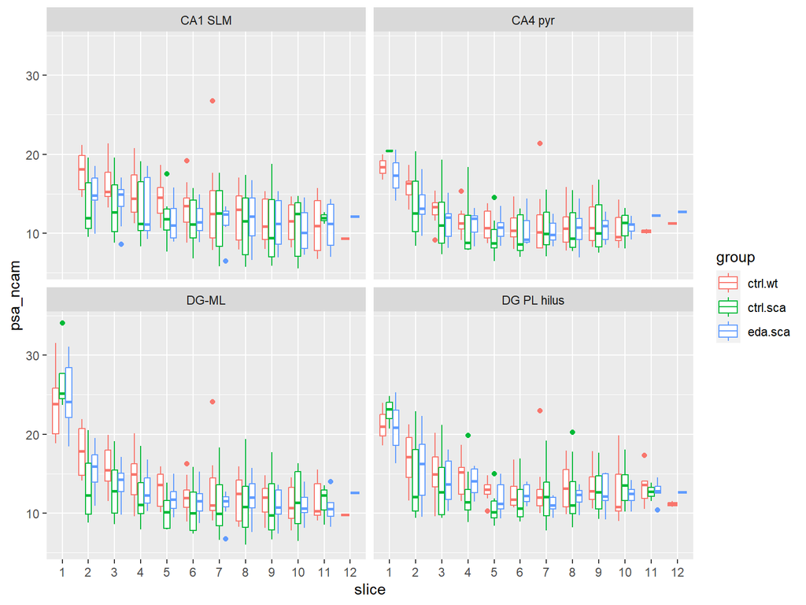

```r
psa_nc$slice <- factor(psa_nc$slice, levels=c(as.character(1:14)))

psa_nc %>% filter(
  slice %in% 1:12,
) %>%
  ggplot(aes(x = slice, y = psa_ncam, by = group, color = group))+
  geom_boxplot()+
  facet_wrap(~structure)
```

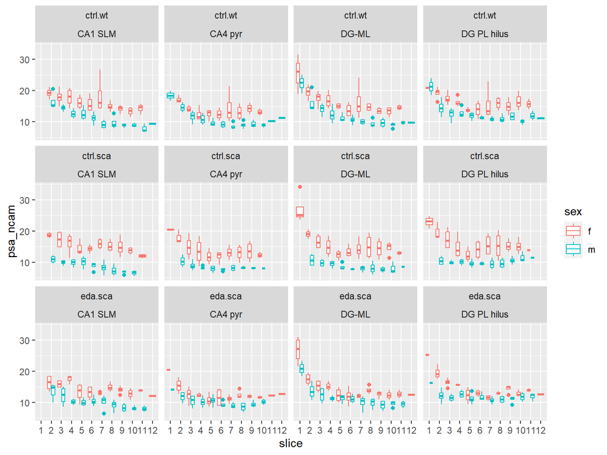

```r
psa_nc %>% filter(
  slice %in% 1:12
) %>%
  ggplot(aes(x = slice, y = psa_ncam, by = sex, color = sex))+
  geom_boxplot()+
  facet_wrap(~group + structure)
```

The PSA-NCAM immunofluorescence (*PSA-NCAM IF*) decreases from frontal to caudal region and is reduced in males. The change from frontal to caudal regions is non-linear and will be included as such, i.e. as thin-plate spline. As the non-linearity is soft, number of knots will be limited to 3.

Distribution seems asymmetrical, with many outliers above median. Gamma regression will be thus used. The question is if:

- 1. to include sex
- 2. use random intercept of *id*, or nested (*slice* nested in *id*).

As the *slice* is already fixed-effect factor, and the numbers of measurements per slice and structure is just 2, default setting will be simple random intercept *id*.

# 3 CA-SRLM

## 3.1 Modelling

Firstly, we will fit and compare 3 models:

- 1. sex included, simple random intercept *id*
- 2. sex NOT included, simple random intercept *id*
- 3. sex included, random effect of *slice* nested in *id*

### 3.1.1 Setting priors

Summary statistics for prior specification

```r
sd(log(ca1_slm$psa_ncam))*c(5)
```

```
[1] 1.535168
```

```r
log(mean(ca1_slm$psa_ncam))
```

```
[1] 2.541232
```

Setting the priors

```r
ca1_slm$group<-relevel(ca1_slm$group,ref='ctrl.sca')

prior01 <- c(set_prior("student_t(3, 2.5, 1.5)", class = "b", coef = "Intercept"),
             set_prior("normal(0.2, 2)", class = "b", coef = "groupctrl.wt"),
             set_prior("normal(0, 1.2)"  , class = "b", coef = "groupeda.sca"),
             set_prior("normal(0, 1.2)"  , class = "b", coef = "sex_num"))

prior02 <- c(set_prior("student_t(3, 2.5, 1.5)", class = "b", coef = "Intercept"),
             set_prior("normal(0.2, 2)", class = "b", coef = "groupctrl.wt"),
             set_prior("normal(0, 1.2)"  , class = "b", coef = "groupeda.sca"))
```

### 3.1.2 Models fitting and convergence diagnostics

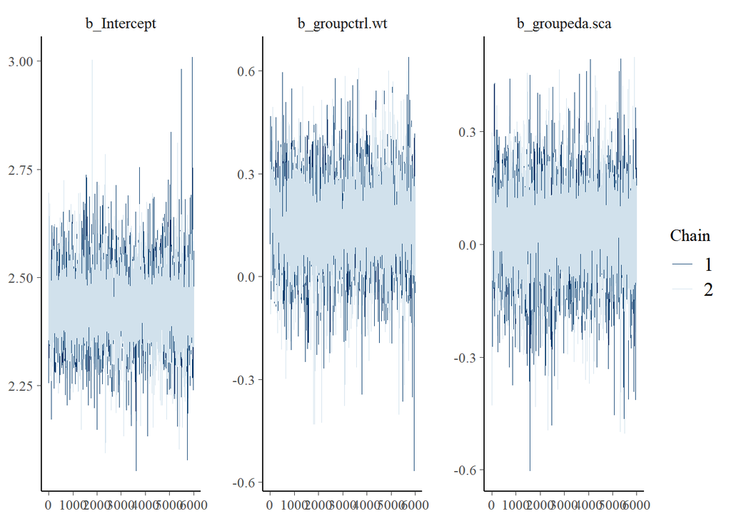

```r
## fitting models
psa_ca1_slm1 <- run_model(
        brm(psa_ncam~0+Intercept+group+ s(slice_n, k=3) + sex_num + (1|id),
                  data= ca1_slm, prior = prior01,
                  family=Gamma(link = 'log'),
                  save_pars = save_pars(all = TRUE),
                  iter=8000, warmup=2000,chains=2,cores=2,seed=17,
                  control = list(adapt_delta = 0.99)),
                   'output/brm/psa_ca1_slm1', reuse = TRUE)

psa_ca1_slm2 <- run_model(
        brm(psa_ncam~0+Intercept+group+ s(slice_n, k=3) + (1|id),
                  data= ca1_slm, prior = prior02,
                  family=Gamma(link = 'log'),
                  save_pars = save_pars(all = TRUE),
                  iter=8000, warmup=2000,chains=2,cores=2,seed=17,
                  control = list(adapt_delta = 0.99)),
                   'output/brm/psa_ca1_slm2', reuse = TRUE)

psa_ca1_slm3 <- run_model(
        brm(psa_ncam~0+Intercept+group+ s(slice_n, k=3) + sex_num + (1|id/slice),
                  data= ca1_slm, prior = prior01,
                  family=Gamma(link = 'log'),
                  save_pars = save_pars(all = TRUE),
                  iter=8000, warmup=2000,chains=2,cores=2,seed=17,
                  control = list(adapt_delta = 0.99)),
                   'output/brm/psa_ca1_slm3', reuse = TRUE)

## chains for crucial fixed-effect predictors
mcmc_trace(psa_ca1_slm1, pars = c('b_Intercept',
                               'b_groupctrl.wt',
                               'b_groupeda.sca'))
```

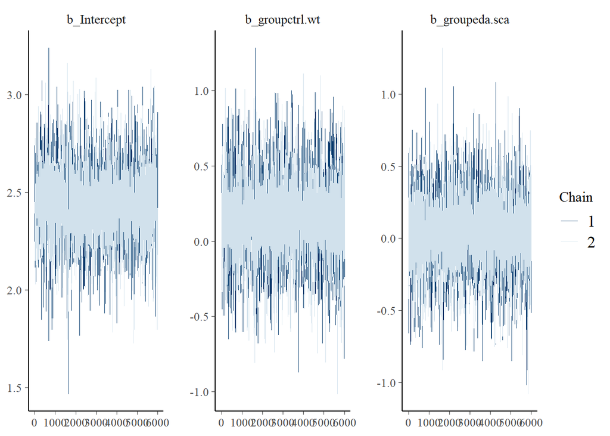

```r
mcmc_trace(psa_ca1_slm2, pars = c('b_Intercept',
                               'b_groupctrl.wt',
                               'b_groupeda.sca'))
```

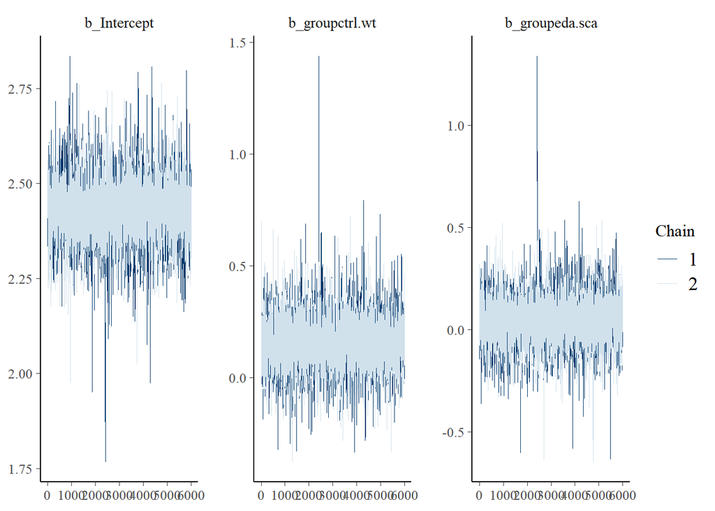

```r
mcmc_trace(psa_ca1_slm3, pars = c('b_Intercept',
                               'b_groupctrl.wt',
                               'b_groupeda.sca'))
```

```r
## summary of models
summary(psa_ca1_slm1)
```

```
 Family: gamma
  Links: mu = log; shape = identity
Formula: psa_ncam ~ 0 + Intercept + group + s(slice_n, k = 3) + sex_num + (1 | id)
   Data: ca1_slm (Number of observations: 225)
  Draws: 2 chains, each with iter = 8000; warmup = 2000; thin = 1;
         total post-warmup draws = 12000

Smooth Terms:
                Estimate Est.Error l-95% CI u-95% CI Rhat Bulk_ESS Tail_ESS
sds(sslice_n_1)     1.72      1.55     0.30     5.82 1.00     5659     6315

Group-Level Effects:
~id (Number of levels: 12)
              Estimate Est.Error l-95% CI u-95% CI Rhat Bulk_ESS Tail_ESS
sd(Intercept)     0.14      0.05     0.08     0.27 1.00     3223     4039

Population-Level Effects:
             Estimate Est.Error l-95% CI u-95% CI Rhat Bulk_ESS Tail_ESS
Intercept        2.44      0.08     2.29     2.60 1.00     4683     5495
groupctrl.wt     0.15      0.11    -0.07     0.38 1.00     4361     4862
groupeda.sca     0.04      0.11    -0.19     0.25 1.00     4900     5270
sex_num         -0.44      0.09    -0.62    -0.26 1.00     5396     5466
sslice_n_1       0.09      0.01     0.07     0.12 1.00    12944     8007

Family Specific Parameters:
      Estimate Est.Error l-95% CI u-95% CI Rhat Bulk_ESS Tail_ESS
shape    54.28      5.37    44.25    65.33 1.00    13061     7600

Draws were sampled using sampling(NUTS). For each parameter, Bulk_ESS
and Tail_ESS are effective sample size measures, and Rhat is the potential
scale reduction factor on split chains (at convergence, Rhat = 1).
```

```r
summary(psa_ca1_slm2)
```

```
 Family: gamma
  Links: mu = log; shape = identity
Formula: psa_ncam ~ 0 + Intercept + group + s(slice_n, k = 3) + (1 | id)
   Data: ca1_slm (Number of observations: 225)
  Draws: 2 chains, each with iter = 8000; warmup = 2000; thin = 1;
         total post-warmup draws = 12000

Smooth Terms:
                Estimate Est.Error l-95% CI u-95% CI Rhat Bulk_ESS Tail_ESS
sds(sslice_n_1)     1.73      1.60     0.29     6.07 1.00     5645     5398

Group-Level Effects:
~id (Number of levels: 12)
              Estimate Est.Error l-95% CI u-95% CI Rhat Bulk_ESS Tail_ESS
sd(Intercept)     0.32      0.09     0.20     0.55 1.00     3187     5228

Population-Level Effects:
             Estimate Est.Error l-95% CI u-95% CI Rhat Bulk_ESS Tail_ESS
Intercept        2.44      0.16     2.12     2.77 1.00     3953     5188
groupctrl.wt     0.16      0.23    -0.32     0.62 1.00     4166     5083
groupeda.sca     0.04      0.23    -0.41     0.49 1.00     4362     5381
sslice_n_1       0.09      0.01     0.07     0.12 1.00    11321     6703

Family Specific Parameters:
      Estimate Est.Error l-95% CI u-95% CI Rhat Bulk_ESS Tail_ESS
shape    54.19      5.24    44.34    64.98 1.00    11244     7402

Draws were sampled using sampling(NUTS). For each parameter, Bulk_ESS
and Tail_ESS are effective sample size measures, and Rhat is the potential
scale reduction factor on split chains (at convergence, Rhat = 1).
```

```r
summary(psa_ca1_slm3)
```

```
 Family: gamma
  Links: mu = log; shape = identity
Formula: psa_ncam ~ 0 + Intercept + group + s(slice_n, k = 3) + sex_num + (1 | id/slice)
   Data: ca1_slm (Number of observations: 225)
  Draws: 2 chains, each with iter = 8000; warmup = 2000; thin = 1;
         total post-warmup draws = 12000

Smooth Terms:
                Estimate Est.Error l-95% CI u-95% CI Rhat Bulk_ESS Tail_ESS
sds(sslice_n_1)     1.72      1.53     0.26     5.76 1.00     7771     6916

Group-Level Effects:
~id (Number of levels: 12)
              Estimate Est.Error l-95% CI u-95% CI Rhat Bulk_ESS Tail_ESS
sd(Intercept)     0.14      0.05     0.08     0.27 1.00     4021     5083

~id:slice (Number of levels: 119)
              Estimate Est.Error l-95% CI u-95% CI Rhat Bulk_ESS Tail_ESS
sd(Intercept)     0.06      0.02     0.02     0.09 1.00     1476      999

Population-Level Effects:
             Estimate Est.Error l-95% CI u-95% CI Rhat Bulk_ESS Tail_ESS
Intercept        2.43      0.08     2.27     2.59 1.00     4416     5274
groupctrl.wt     0.16      0.11    -0.05     0.38 1.00     4570     5374
groupeda.sca     0.05      0.11    -0.18     0.26 1.00     4330     4778
sex_num         -0.44      0.09    -0.62    -0.27 1.00     5477     5911
sslice_n_1       0.09      0.01     0.07     0.12 1.00    13668     9925

Family Specific Parameters:
      Estimate Est.Error l-95% CI u-95% CI Rhat Bulk_ESS Tail_ESS
shape    67.12      9.19    50.42    86.12 1.00     2897     4478

Draws were sampled using sampling(NUTS). For each parameter, Bulk_ESS
and Tail_ESS are effective sample size measures, and Rhat is the potential
scale reduction factor on split chains (at convergence, Rhat = 1).
```

Convergence and ESS are OK except the last model (with hierarchical random effects) where tail ESS for SD(Intercept) is low. Conclusions from all models would be similar.

### 3.1.3 PPC

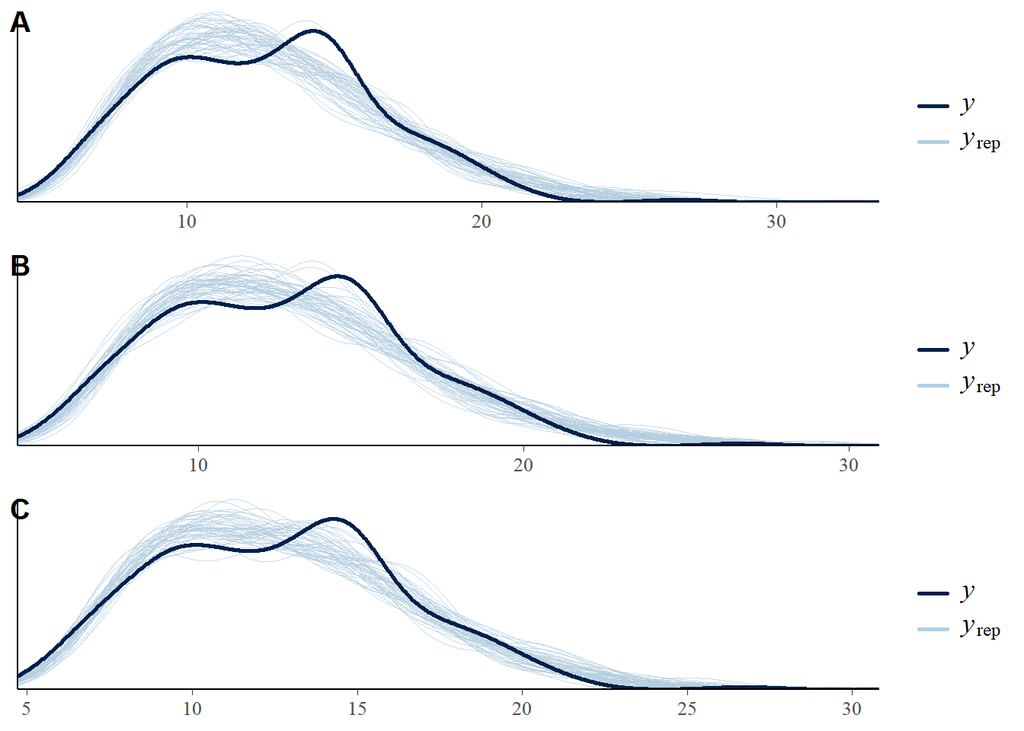

```r
pla<-pp_check(psa_ca1_slm1,type='dens_overlay',ndraws = 50)
plb<-pp_check(psa_ca1_slm2,type='dens_overlay',ndraws = 50)
plc<-pp_check(psa_ca1_slm3,type='dens_overlay',ndraws = 50)
plot_grid(pla, plb, plc, labels=c("A", "B", "C"), ncol = 1, nrow = 3)
```

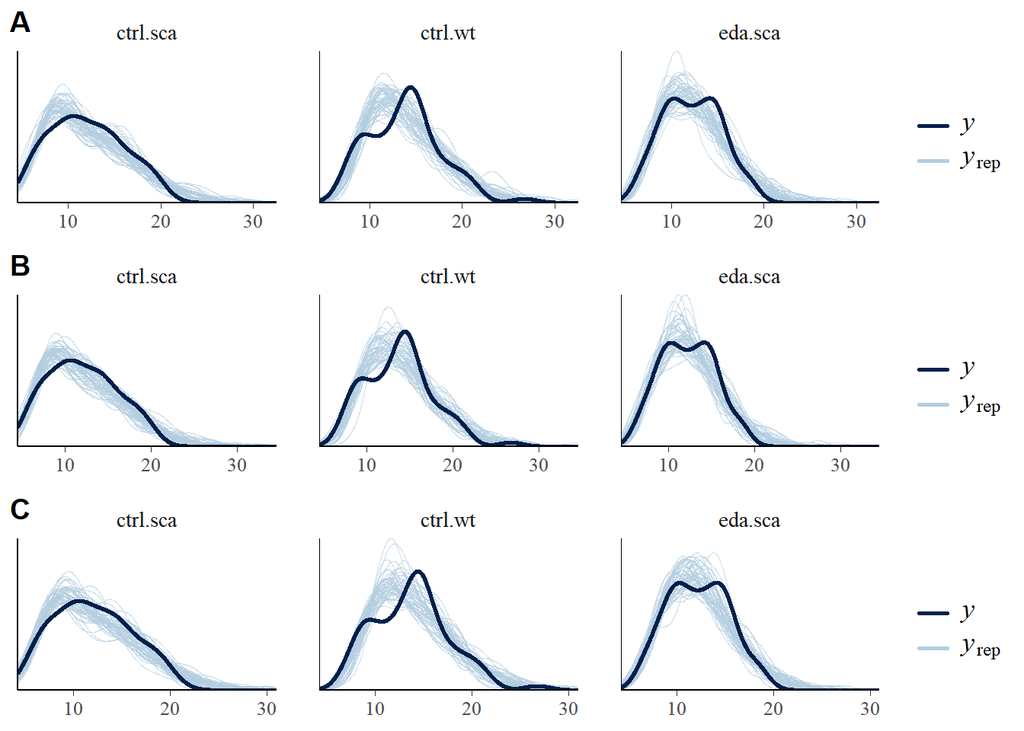

```r
pla<-pp_check(psa_ca1_slm1,type='dens_overlay_grouped',ndraws = 50,group='group')
plb<-pp_check(psa_ca1_slm2,type='dens_overlay_grouped',ndraws = 50,group='group')
plc<-pp_check(psa_ca1_slm2,type='dens_overlay_grouped',ndraws = 50,group='group')
plot_grid(pla, plb, plc, labels= c("A", "B", "C"), ncol = 1, nrow = 3)
```

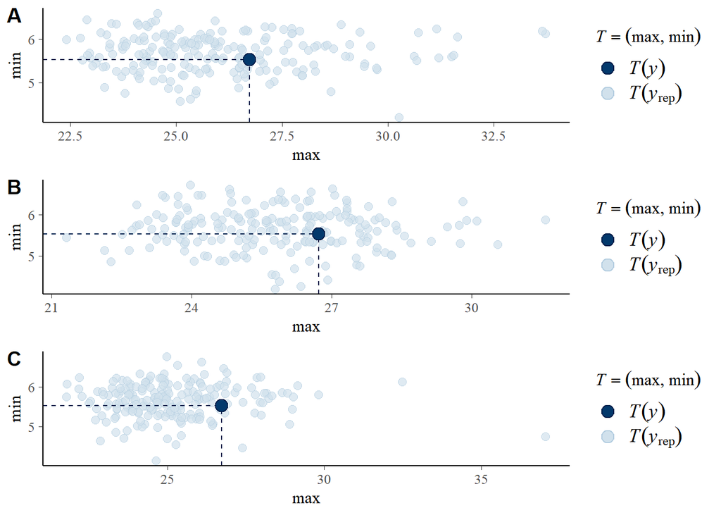

```r
pla<-pp_check(psa_ca1_slm1,type="stat_2d", stat = c("max", "min"),ndraws=200)
plb<-pp_check(psa_ca1_slm2,type="stat_2d", stat = c("max", "min"),ndraws=200)
plc<-pp_check(psa_ca1_slm3,type="stat_2d", stat = c("max", "min"),ndraws=200)
plot_grid(pla, plb, plc, labels=c("A", "B", "C"), ncol = 1, nrow = 3)
```

```r
### Are there too influential observations?
par(mfrow=c(1,3))
plot(loo(psa_ca1_slm1));loo(psa_ca1_slm1)
```

```
Computed from 12000 by 225 log-likelihood matrix

         Estimate   SE
elpd_loo   -441.0 13.9
p_loo        15.9  2.6
looic       882.0 27.8
------
Monte Carlo SE of elpd_loo is NA.

Pareto k diagnostic values:
                         Count Pct.    Min. n_eff
(-Inf, 0.5]   (good)     223   99.1%   6694
 (0.5, 0.7]   (ok)         1    0.4%   1334
   (0.7, 1]   (bad)        1    0.4%   233
   (1, Inf)   (very bad)   0    0.0%   <NA>
See help('pareto-k-diagnostic') for details.
```

```r
plot(loo(psa_ca1_slm2));loo(psa_ca1_slm2)
```

```
Computed from 12000 by 225 log-likelihood matrix

         Estimate   SE
elpd_loo   -441.2 13.8
p_loo        16.2  2.7
looic       882.4 27.6
------
Monte Carlo SE of elpd_loo is 0.1.

Pareto k diagnostic values:
                         Count Pct.    Min. n_eff
(-Inf, 0.5]   (good)     224   99.6%   1586
 (0.5, 0.7]   (ok)         1    0.4%   270
   (0.7, 1]   (bad)        0    0.0%   <NA>
   (1, Inf)   (very bad)   0    0.0%   <NA>

All Pareto k estimates are ok (k < 0.7).
See help('pareto-k-diagnostic') for details.
```

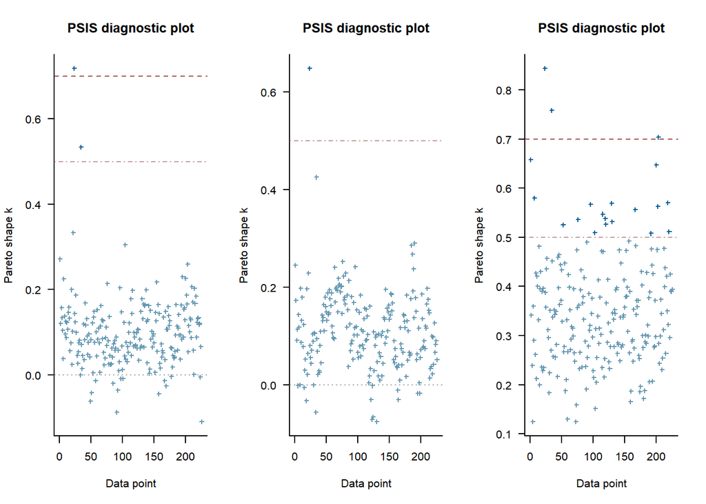

```
Computed from 12000 by 225 log-likelihood matrix

         Estimate   SE
elpd_loo   -437.1 13.5
p_loo        47.1  5.3
looic       874.2 27.0
------
Monte Carlo SE of elpd_loo is NA.

Pareto k diagnostic values:
                         Count Pct.    Min. n_eff
(-Inf, 0.5]   (good)     205   91.1%   1802
 (0.5, 0.7]   (ok)        17    7.6%   600
   (0.7, 1]   (bad)        3    1.3%   115
   (1, Inf)   (very bad)   0    0.0%   <NA>
See help('pareto-k-diagnostic') for details.
```

```r
plot(loo(psa_ca1_slm3));loo(psa_ca1_slm3)
```

### 3.1.4 Models comparison

```r
psa_ca1_slm1 <- add_criterion(psa_ca1_slm1, criterion = "loo")
psa_ca1_slm2 <- add_criterion(psa_ca1_slm2, criterion = "loo")

loo_compare(psa_ca1_slm1, psa_ca1_slm2)
```

```
             elpd_diff se_diff
psa_ca1_slm1  0.0       0.0
psa_ca1_slm2 -0.2       0.6
```

They are comparable (model with sex very slighlty better). However, given the fact that there often no overlap between sexes (per given structure and order of slice) and the clear effect of sex, sex will be included to final models

### 3.1.5 Extraction of posterior samples

```r
post_fix_ca1_slm <- as.data.frame(psa_ca1_slm1, variable = c("b_Intercept","b_groupctrl.wt",
                                                      "b_groupeda.sca"), )
names(post_fix_ca1_slm)[1]<-"sca_ctrl"

post_fix_ca1_slm$wt_ctrl<-post_fix_ca1_slm$sca_ctrl+post_fix_ca1_slm$b_groupctrl.wt
post_fix_ca1_slm$sca_eda<-post_fix_ca1_slm$sca_ctrl+post_fix_ca1_slm$b_groupeda.sca
summary(post_fix_ca1_slm)
```

```
    sca_ctrl     b_groupctrl.wt     b_groupeda.sca        wt_ctrl
 Min.   :2.053   Min.   :-0.56639   Min.   :-0.60253   Min.   :1.972
 1st Qu.:2.390   1st Qu.: 0.08902   1st Qu.:-0.02695   1st Qu.:2.543
 Median :2.435   Median : 0.15553   Median : 0.03739   Median :2.592
 Mean   :2.436   Mean   : 0.15458   Mean   : 0.03779   Mean   :2.591
 3rd Qu.:2.481   3rd Qu.: 0.22154   3rd Qu.: 0.10441   3rd Qu.:2.639
 Max.   :3.009   Max.   : 0.63941   Max.   : 0.49835   Max.   :3.139
    sca_eda
 Min.   :1.994
 1st Qu.:2.427
 Median :2.474
 Mean   :2.474
 3rd Qu.:2.521
 Max.   :2.911
```

```r
groupquant_ca1_slm<-sapply(post_fix_ca1_slm[,c(4,1,5)],
                           function(p) quantile(p, probs = c(0.025,0.975,0.5)))
groupquant_ca1_slm <- exp(groupquant_ca1_slm)
```

# 4 CA4

## 4.1 Modelling

Summary statistics to get prior

```r
c4_pyr$group<-relevel(c4_pyr$group,ref='ctrl.sca')


sd(log(c4_pyr$psa_ncam))*c(5)
```

```
[1] 1.285989
```

```r
log(mean(c4_pyr$psa_ncam))
```

```
[1] 2.443142
```

### 4.1.1 Prior setting

```r
c4_pyr$group<-relevel(c4_pyr$group,ref='ctrl.sca')

prior01 <- c(set_prior("student_t(3, 2.4, 1.3)", class = "b", coef = "Intercept"),
             set_prior("normal(0.2, 2)", class = "b", coef = "groupctrl.wt"),
             set_prior("normal(0, 1.2)"  , class = "b", coef = "groupeda.sca"),
             set_prior("normal(0, 1.2)"  , class = "b", coef = "sex_num"))
```

### 4.1.2 Model fit and convergence check

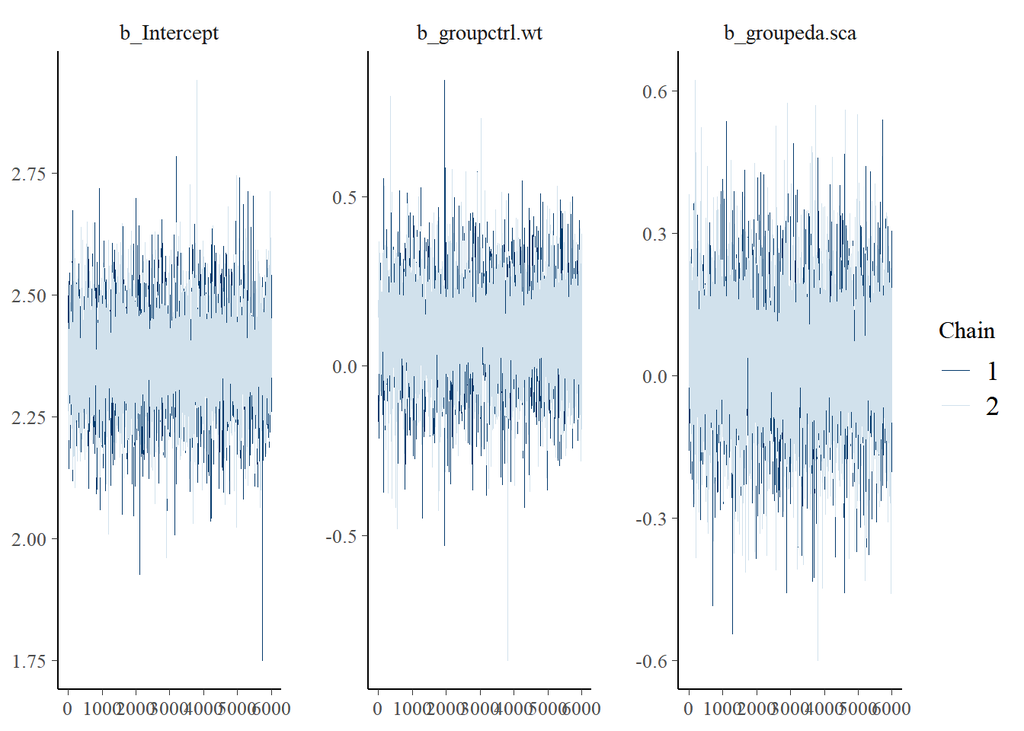

```r
psa_c4_pyr <- run_model(
        brm(psa_ncam~0+Intercept+group+ s(slice_n, k=3) + sex_num + (1|id),
                  data= c4_pyr, prior = prior01,
                  family=Gamma(link = 'log'),
                  save_pars = save_pars(all = TRUE),
                  iter=8000, warmup=2000,chains=2,cores=2,seed=17,
                  control = list(adapt_delta = 0.99)),
                   'output/brm/psa_c4_pyr', reuse = TRUE)

## chains for crucial fixed-effect predictors
mcmc_trace(psa_c4_pyr, pars = c('b_Intercept',
                               'b_groupctrl.wt',
                               'b_groupeda.sca'))
```

```r
## summary of models
summary(psa_c4_pyr)
```

```
 Family: gamma
  Links: mu = log; shape = identity
Formula: psa_ncam ~ 0 + Intercept + group + s(slice_n, k = 3) + sex_num + (1 | id)
   Data: c4_pyr (Number of observations: 212)
  Draws: 2 chains, each with iter = 8000; warmup = 2000; thin = 1;
         total post-warmup draws = 12000

Smooth Terms:
                Estimate Est.Error l-95% CI u-95% CI Rhat Bulk_ESS Tail_ESS
sds(sslice_n_1)     2.64      1.96     0.75     7.37 1.00     7864     5911

Group-Level Effects:
~id (Number of levels: 12)
              Estimate Est.Error l-95% CI u-95% CI Rhat Bulk_ESS Tail_ESS
sd(Intercept)     0.16      0.05     0.09     0.29 1.00     3699     5927

Population-Level Effects:
             Estimate Est.Error l-95% CI u-95% CI Rhat Bulk_ESS Tail_ESS
Intercept        2.37      0.09     2.20     2.54 1.00     5470     5715
groupctrl.wt     0.10      0.12    -0.15     0.35 1.00     5495     6362
groupeda.sca     0.04      0.12    -0.21     0.29 1.00     5832     5753
sex_num         -0.33      0.10    -0.52    -0.12 1.00     6420     6315
sslice_n_1       0.02      0.01    -0.01     0.04 1.00    14019     8377

Family Specific Parameters:
      Estimate Est.Error l-95% CI u-95% CI Rhat Bulk_ESS Tail_ESS
shape    63.46      6.31    51.64    76.36 1.00    13105     8392

Draws were sampled using sampling(NUTS). For each parameter, Bulk_ESS
and Tail_ESS are effective sample size measures, and Rhat is the potential
scale reduction factor on split chains (at convergence, Rhat = 1).
```

Everything is OK

### 4.1.3 PPC

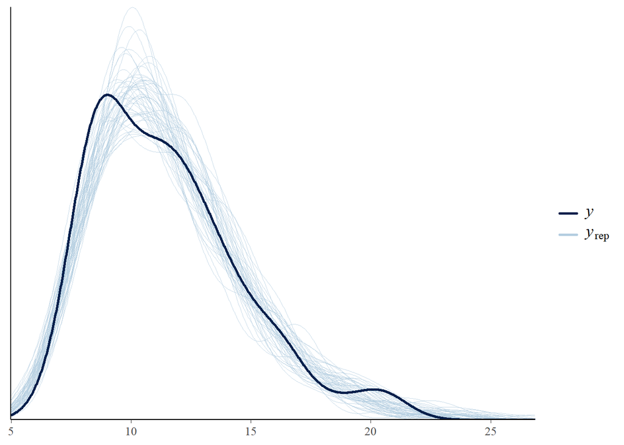

```r
pp_check(psa_c4_pyr,type='dens_overlay',ndraws = 50)
```

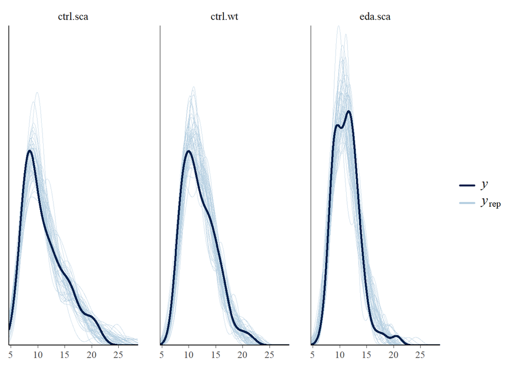

```r
pp_check(psa_c4_pyr,type='dens_overlay_grouped',ndraws = 50,group='group')
```

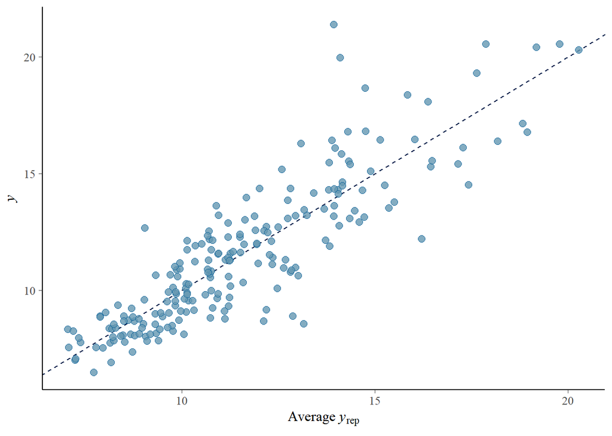

```r
pp_check(psa_c4_pyr,type='scatter_avg', ndraws = 50)
```

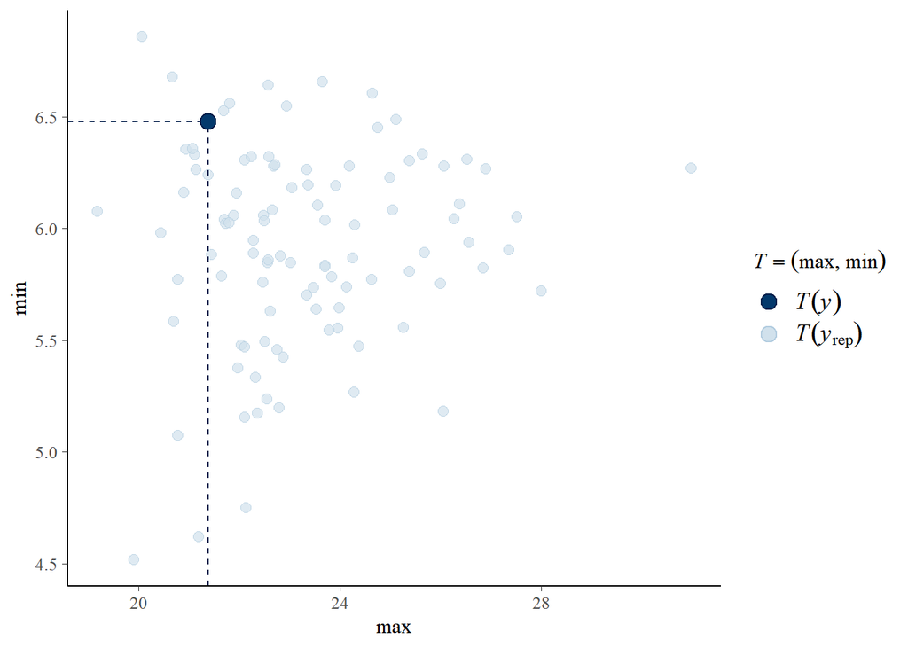

```r
pp_check(psa_c4_pyr,type="stat_2d", stat = c("max", "min"),ndraws=100)
```

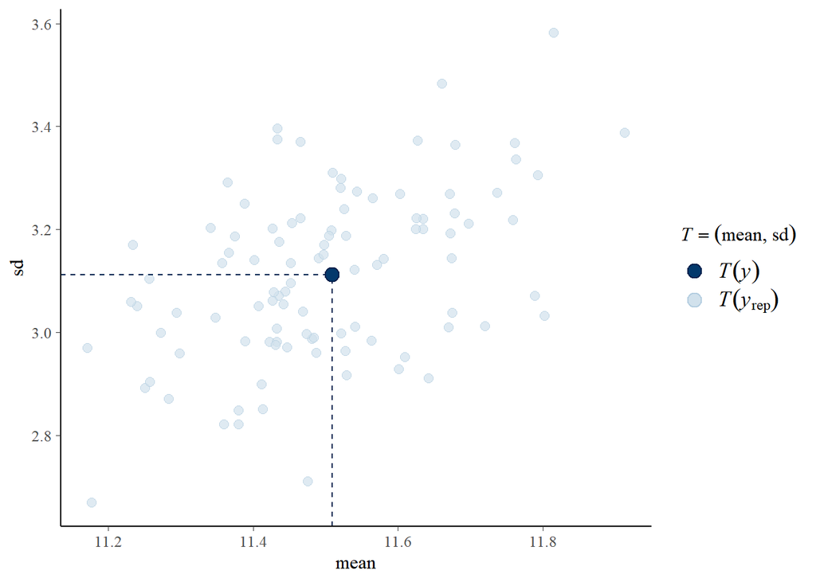

```r
pp_check(psa_c4_pyr,type="stat_2d", stat = c("mean", "sd"),ndraws=100)
```

PPC seems mostly OK

### 4.1.4 Posterior draws extraction

```r
post_fix_c4_pyr <- as.data.frame(psa_c4_pyr, variable = c("b_Intercept","b_groupctrl.wt",
                                                        "b_groupeda.sca"), )
names(post_fix_c4_pyr)[1]<-"sca_ctrl"

post_fix_c4_pyr$wt_ctrl<-post_fix_c4_pyr$sca_ctrl+post_fix_c4_pyr$b_groupctrl.wt
post_fix_c4_pyr$sca_eda<-post_fix_c4_pyr$sca_ctrl+post_fix_c4_pyr$b_groupeda.sca
summary(post_fix_c4_pyr)
```

```
    sca_ctrl     b_groupctrl.wt     b_groupeda.sca        wt_ctrl
 Min.   :1.749   Min.   :-0.86867   Min.   :-0.60046   Min.   :1.940
 1st Qu.:2.319   1st Qu.: 0.02802   1st Qu.:-0.03635   1st Qu.:2.419
 Median :2.370   Median : 0.10209   Median : 0.03751   Median :2.474
 Mean   :2.371   Mean   : 0.10134   Mean   : 0.03697   Mean   :2.472
 3rd Qu.:2.423   3rd Qu.: 0.17538   3rd Qu.: 0.11094   3rd Qu.:2.525
 Max.   :2.940   Max.   : 0.84255   Max.   : 0.62312   Max.   :3.034
    sca_eda
 Min.   :1.904
 1st Qu.:2.355
 Median :2.408
 Mean   :2.408
 3rd Qu.:2.460
 Max.   :2.873
```

```r
groupquant_c4_pyr<-sapply(post_fix_c4_pyr[,c(4,1,5)],
                        function(p) quantile(p, probs = c(0.025,0.975,0.5)))
groupquant_c4_pyr <- exp(groupquant_c4_pyr)
```

# 5 DG ML

## 5.1 Modelling

Summary statistics to get prior

```r
dg_ml$group<-relevel(dg_ml$group,ref='ctrl.sca')
summary(dg_ml)
```

```
    hist_id         slice     side       part.ID          structure
 Min.   :6367   3      : 24   l:122          :172   CA1 SLM    :  0
 1st Qu.:6370   6      : 24   p:123   1      : 56   CA4 pyr    :  0
 Median :6377   7      : 24           2      : 14   DG-ML      :245
 Mean   :6385   8      : 24           3      :  1   DG PL hilus:  0
 3rd Qu.:6401   9      : 24           control:  2
 Max.   :6417   10     : 23
                (Other):102
      area        psa_ncam            id       treat     genotype  sex
 27914  :  2   Min.   : 6.026   9      : 26   ctrl:162   sca:158   f:122
 100295 :  1   1st Qu.:10.189   13     : 22   eda : 83   wt : 87   m:123
 10185  :  1   Median :12.257   19     : 21
 105686 :  1   Mean   :13.217   29     : 21
 105824 :  1   3rd Qu.:15.100   31     : 21
 10872  :  1   Max.   :34.074   11     : 20
 (Other):238                    (Other):114
    slice_n           group       sex_num               group_sex
 Min.   : 1.00   ctrl.sca:75   Min.   :-0.500000   ctrl.wt.m :46
 1st Qu.: 3.00   ctrl.wt :87   1st Qu.:-0.500000   eda.sca.f :42
 Median : 6.00   eda.sca :83   Median : 0.500000   ctrl.wt.f :41
 Mean   : 6.11                 Mean   : 0.002041   eda.sca.m :41
 3rd Qu.: 9.00                 3rd Qu.: 0.500000   ctrl.sca.f:39
 Max.   :14.00                 Max.   : 0.500000   ctrl.sca.m:36
                                                   (Other)   : 0
```

```r
sd(log(dg_ml$psa_ncam))*c(5)
```

```
[1] 1.603249
```

```r
log(mean(dg_ml$psa_ncam))
```

```
[1] 2.5815
```

### 5.1.1 Prior setting

```r
dg_ml$group<-relevel(dg_ml$group,ref='ctrl.sca')

prior01 <- c(set_prior("student_t(3, 2.6, 1.6)", class = "b", coef = "Intercept"),
             set_prior("normal(0, 2)", class = "b", coef = "groupctrl.wt"),
             set_prior("normal(0, 1.2)"  , class = "b", coef = "groupeda.sca"),
             set_prior("normal(0, 1.2)"  , class = "b", coef = "sex_num"))
```

### 5.1.2 Model fit and convergence check

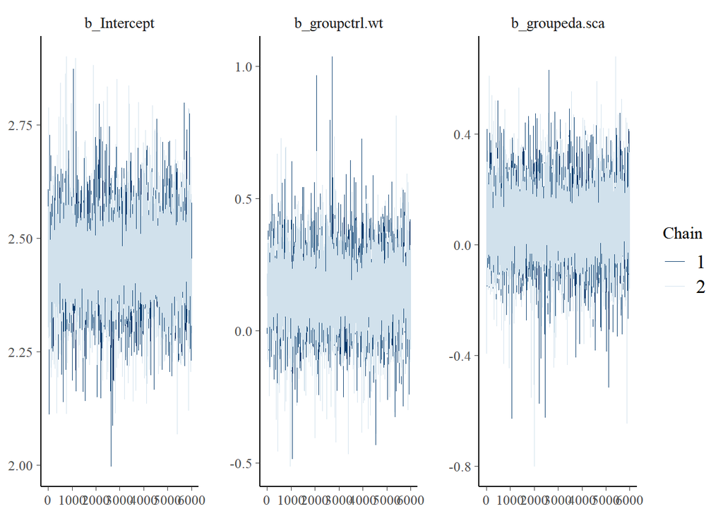

```r
psa_dgml <- run_model(
        brm(psa_ncam~0+Intercept+group+ s(slice_n, k=3) + sex_num + (1|id),
                  data= dg_ml, prior = prior01,
                  family=Gamma(link = 'log'),
                  save_pars = save_pars(all = TRUE),
                  iter=8000, warmup=2000,chains=2,cores=2,seed=17,
                  control = list(adapt_delta = 0.99)),
                   'output/brm/psa_dgml', reuse = TRUE)

## chains for crucial fixed-effect predictors
mcmc_trace(psa_dgml, pars = c('b_Intercept',
                               'b_groupctrl.wt',
                               'b_groupeda.sca'))
```

```r
## summary of models
summary(psa_dgml)
```

```
 Family: gamma
  Links: mu = log; shape = identity
Formula: psa_ncam ~ 0 + Intercept + group + s(slice_n, k = 3) + sex_num + (1 | id)
   Data: dg_ml (Number of observations: 245)
  Draws: 2 chains, each with iter = 8000; warmup = 2000; thin = 1;
         total post-warmup draws = 12000

Smooth Terms:
                Estimate Est.Error l-95% CI u-95% CI Rhat Bulk_ESS Tail_ESS
sds(sslice_n_1)     2.76      1.89     0.85     7.96 1.00     7821     6927

Group-Level Effects:
~id (Number of levels: 12)
              Estimate Est.Error l-95% CI u-95% CI Rhat Bulk_ESS Tail_ESS
sd(Intercept)     0.16      0.05     0.09     0.29 1.00     3878     4961

Population-Level Effects:
             Estimate Est.Error l-95% CI u-95% CI Rhat Bulk_ESS Tail_ESS
Intercept        2.45      0.09     2.28     2.63 1.00     4979     5062
groupctrl.wt     0.15      0.12    -0.09     0.40 1.00     5343     5255
groupeda.sca     0.08      0.12    -0.16     0.32 1.00     5388     5673
sex_num         -0.39      0.10    -0.59    -0.19 1.00     6145     6295
sslice_n_1       0.08      0.01     0.06     0.10 1.00    15180     7697

Family Specific Parameters:
      Estimate Est.Error l-95% CI u-95% CI Rhat Bulk_ESS Tail_ESS
shape    55.09      5.05    45.46    65.48 1.00    14873     7904

Draws were sampled using sampling(NUTS). For each parameter, Bulk_ESS
and Tail_ESS are effective sample size measures, and Rhat is the potential
scale reduction factor on split chains (at convergence, Rhat = 1).
```

Everything is OK

### 5.1.3 PPC

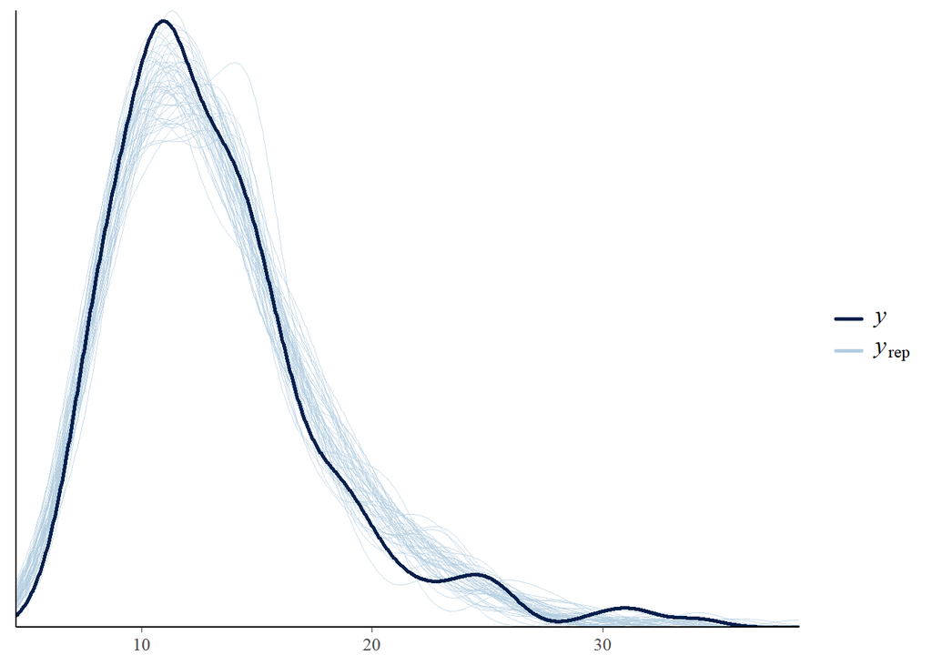

```r
pp_check(psa_dgml,type='dens_overlay',ndraws = 50)
```

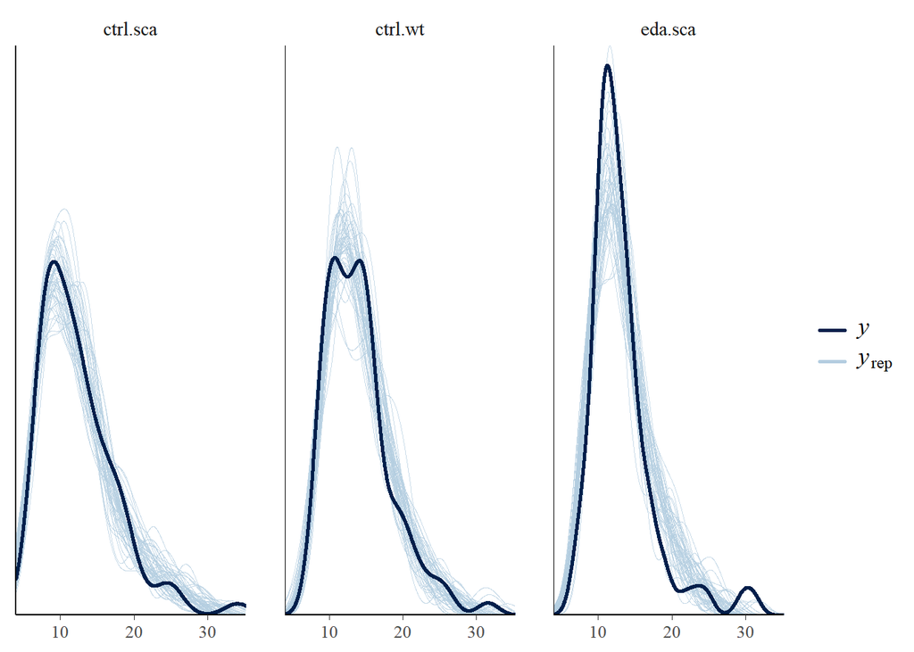

```r
pp_check(psa_dgml,type='dens_overlay_grouped',ndraws = 50,group='group')
```

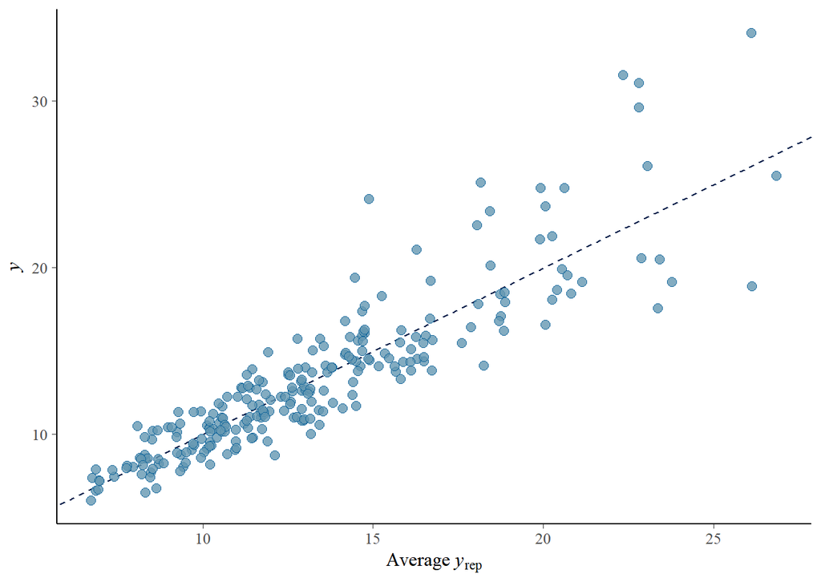

```r
pp_check(psa_dgml,type='scatter_avg', ndraws = 50)
```

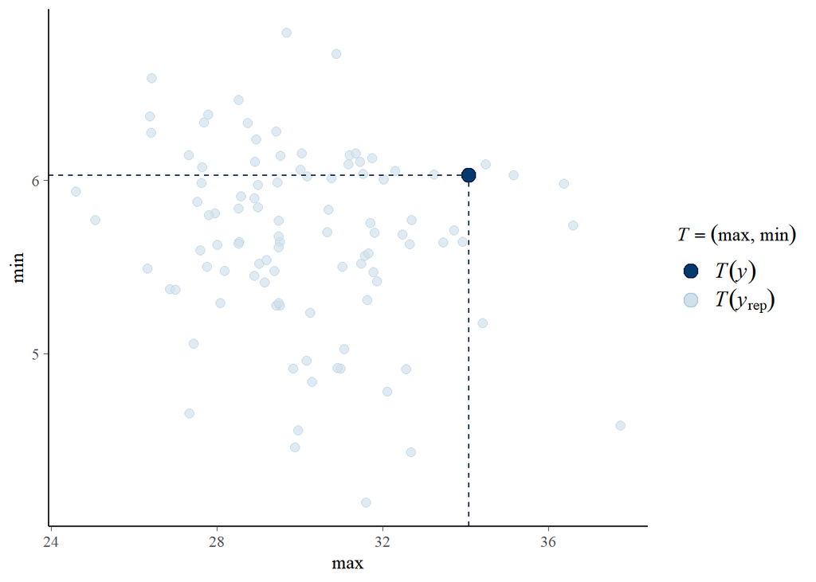

```r
pp_check(psa_dgml,type="stat_2d", stat = c("max", "min"),ndraws=100)
```

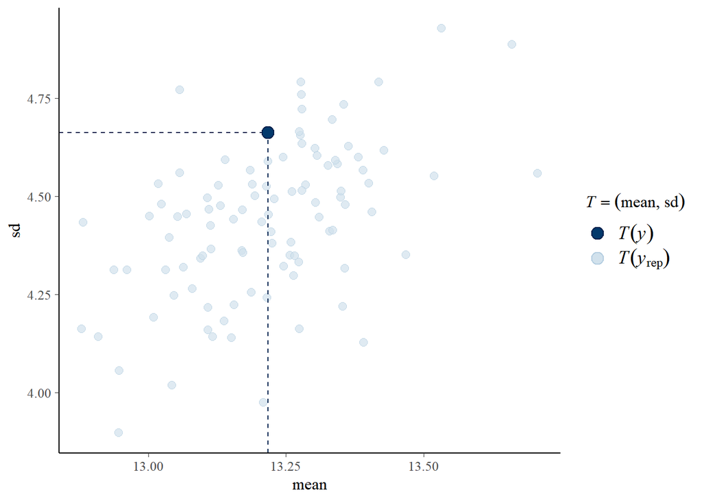

```r
pp_check(psa_dgml,type="stat_2d", stat = c("mean", "sd"),ndraws=100)
```

PPC seems mostly OK

### 5.1.4 Posterior draws extraction

```r
post_fix_dgml <- as.data.frame(psa_dgml, variable = c("b_Intercept","b_groupctrl.wt",
                                                        "b_groupeda.sca"), )
names(post_fix_dgml)[1]<-"sca_ctrl"

post_fix_dgml$wt_ctrl<-post_fix_dgml$sca_ctrl+post_fix_dgml$b_groupctrl.wt
post_fix_dgml$sca_eda<-post_fix_dgml$sca_ctrl+post_fix_dgml$b_groupeda.sca
summary(post_fix_dgml)
```

```
    sca_ctrl     b_groupctrl.wt     b_groupeda.sca         wt_ctrl
 Min.   :1.998   Min.   :-0.51224   Min.   :-0.801047   Min.   :2.156
 1st Qu.:2.401   1st Qu.: 0.07521   1st Qu.: 0.002058   1st Qu.:2.552
 Median :2.454   Median : 0.15215   Median : 0.075857   Median :2.606
 Mean   :2.455   Mean   : 0.15088   Mean   : 0.075644   Mean   :2.605
 3rd Qu.:2.506   3rd Qu.: 0.22610   3rd Qu.: 0.150027   3rd Qu.:2.660
 Max.   :2.900   Max.   : 1.03637   Max.   : 0.678585   Max.   :3.345
    sca_eda
 Min.   :1.934
 1st Qu.:2.478
 Median :2.531
 Mean   :2.530
 3rd Qu.:2.582
 Max.   :3.115
```

```r
groupquant_dgml<-sapply(post_fix_dgml[,c(4,1,5)],
                        function(p) quantile(p, probs = c(0.025,0.975,0.5)))
groupquant_dgml <- exp(groupquant_dgml)
```

# 6 DG hilus

## 6.1 Modelling

Summary statistics to get prior

```r
dg_pl$group<-relevel(dg_pl$group,ref='ctrl.sca')
summary(dg_pl)
```

```
    hist_id         slice    side       part.ID          structure
 Min.   :6367   3      :24   l:120          :164   CA1 SLM    :  0
 1st Qu.:6370   6      :24   p:116   1      : 57   CA4 pyr    :  0
 Median :6377   7      :24           2      : 12   DG-ML      :  0
 Mean   :6385   8      :24           3      :  1   DG PL hilus:236
 3rd Qu.:6401   9      :24           control:  2
 Max.   :6417   2      :23
                (Other):93
      area        psa_ncam            id       treat     genotype  sex
 10047  :  1   Min.   : 7.769   9      : 26   ctrl:158   sca:152   f:114
 10182  :  1   1st Qu.:10.906   13     : 21   eda : 78   wt : 84   m:122
 10717  :  1   Median :12.514   23     : 20
 10830  :  1   Mean   :13.389   31     : 20
 108725 :  1   3rd Qu.:15.076   11     : 19
 11164  :  1   Max.   :25.287   15     : 19
 (Other):230                    (Other):111
    slice_n            group       sex_num              group_sex
 Min.   : 1.000   ctrl.sca:74   Min.   :-0.50000   ctrl.wt.m :46
 1st Qu.: 4.000   ctrl.wt :84   1st Qu.:-0.50000   eda.sca.m :40
 Median : 6.000   eda.sca :78   Median : 0.50000   ctrl.wt.f :38
 Mean   : 6.237                 Mean   : 0.01695   ctrl.sca.f:38
 3rd Qu.: 9.000                 3rd Qu.: 0.50000   eda.sca.f :38
 Max.   :14.000                 Max.   : 0.50000   ctrl.sca.m:36
                                                   (Other)   : 0
```

```r
sd(log(dg_pl$psa_ncam))*c(5)
```

```
[1] 1.210777
```

```r
log(mean(dg_pl$psa_ncam))
```

```
[1] 2.594463
```

### 6.1.1 Prior setting

```r
dg_pl$group<-relevel(dg_pl$group,ref='ctrl.sca')

prior01 <- c(set_prior("student_t(3, 2.6, 1.2)", class = "b", coef = "Intercept"),
             set_prior("normal(0.2, 2)", class = "b", coef = "groupctrl.wt"),
             set_prior("normal(0, 1.2)"  , class = "b", coef = "groupeda.sca"),
             set_prior("normal(0, 1.2)"  , class = "b", coef = "sex_num"))
```

### 6.1.2 Model fit and convergence check

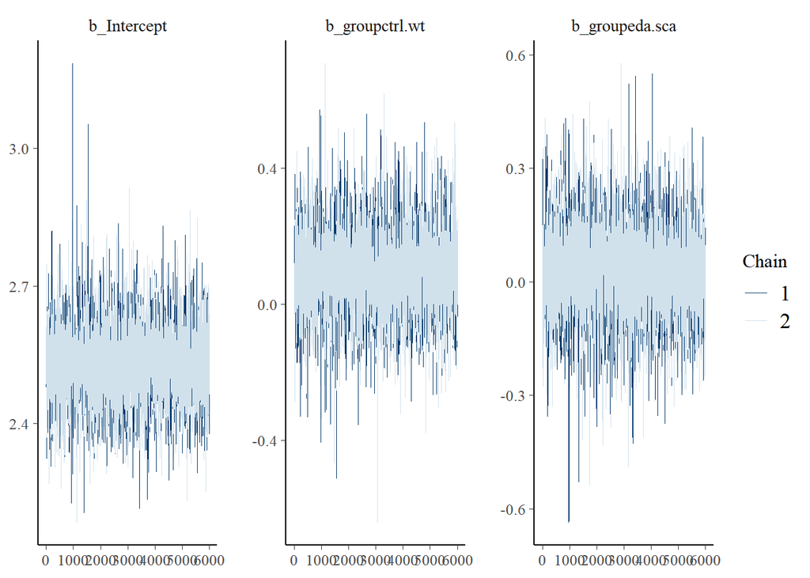

```r
psa_dg_pl <- run_model(
        brm(psa_ncam~0+Intercept+group+ s(slice_n, k=3) + sex_num + (1|id),
                  data= dg_pl, prior = prior01,
                  family=Gamma(link = 'log'),
                  save_pars = save_pars(all = TRUE),
                  iter=8000, warmup=2000,chains=2,cores=2,seed=17,
                  control = list(adapt_delta = 0.99)),
                   'output/brm/psa_dg_pl', reuse = TRUE)

## chains for crucial fixed-effect predictors
mcmc_trace(psa_dg_pl, pars = c('b_Intercept',
                               'b_groupctrl.wt',
                               'b_groupeda.sca'))
```

```r
## summary of models
summary(psa_dg_pl)
```

```
 Family: gamma
  Links: mu = log; shape = identity
Formula: psa_ncam ~ 0 + Intercept + group + s(slice_n, k = 3) + sex_num + (1 | id)
   Data: dg_pl (Number of observations: 236)
  Draws: 2 chains, each with iter = 8000; warmup = 2000; thin = 1;
         total post-warmup draws = 12000

Smooth Terms:
                Estimate Est.Error l-95% CI u-95% CI Rhat Bulk_ESS Tail_ESS
sds(sslice_n_1)     2.32      1.72     0.61     6.73 1.00     7187     6296

Group-Level Effects:
~id (Number of levels: 12)
              Estimate Est.Error l-95% CI u-95% CI Rhat Bulk_ESS Tail_ESS
sd(Intercept)     0.14      0.05     0.08     0.26 1.00     3420     5084

Population-Level Effects:
             Estimate Est.Error l-95% CI u-95% CI Rhat Bulk_ESS Tail_ESS
Intercept        2.53      0.08     2.38     2.68 1.00     5414     5893
groupctrl.wt     0.09      0.11    -0.12     0.31 1.00     5820     5506
groupeda.sca     0.03      0.11    -0.19     0.24 1.00     5816     6086
sex_num         -0.31      0.09    -0.49    -0.13 1.00     6438     6485
sslice_n_1       0.02      0.01     0.00     0.04 1.00    13563     7972

Family Specific Parameters:
      Estimate Est.Error l-95% CI u-95% CI Rhat Bulk_ESS Tail_ESS
shape    62.50      5.93    51.31    74.65 1.00    13157     7843

Draws were sampled using sampling(NUTS). For each parameter, Bulk_ESS
and Tail_ESS are effective sample size measures, and Rhat is the potential
scale reduction factor on split chains (at convergence, Rhat = 1).
```

Everything is OK

### 6.1.3 PPC

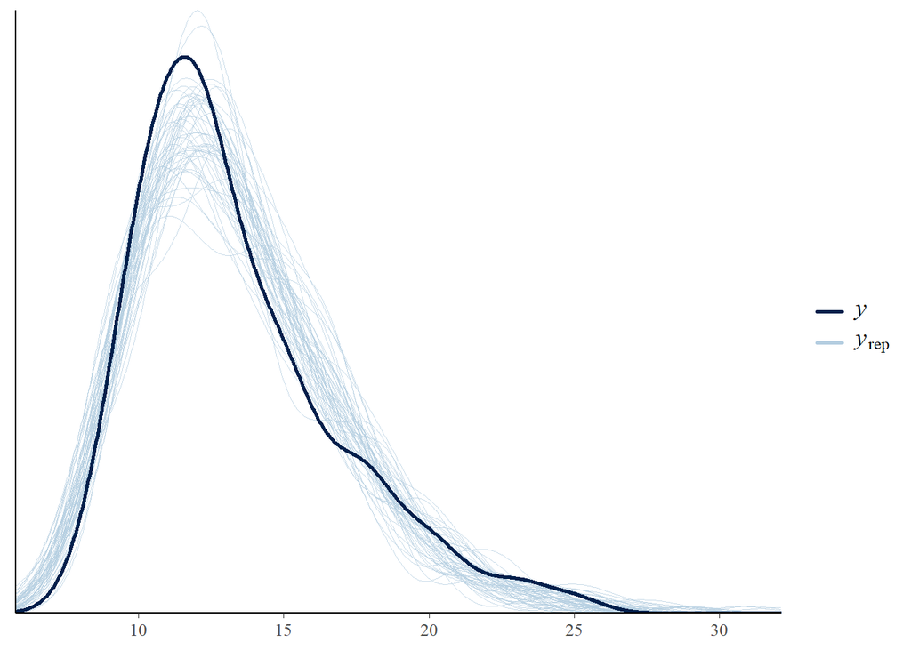

```r
pp_check(psa_dg_pl,type='dens_overlay',ndraws = 50)
```

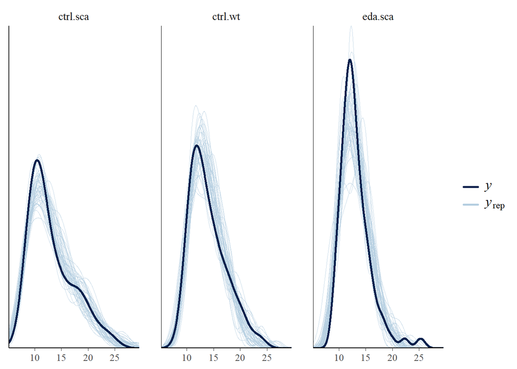

```r
pp_check(psa_dg_pl,type='dens_overlay_grouped',ndraws = 50,group='group')
```

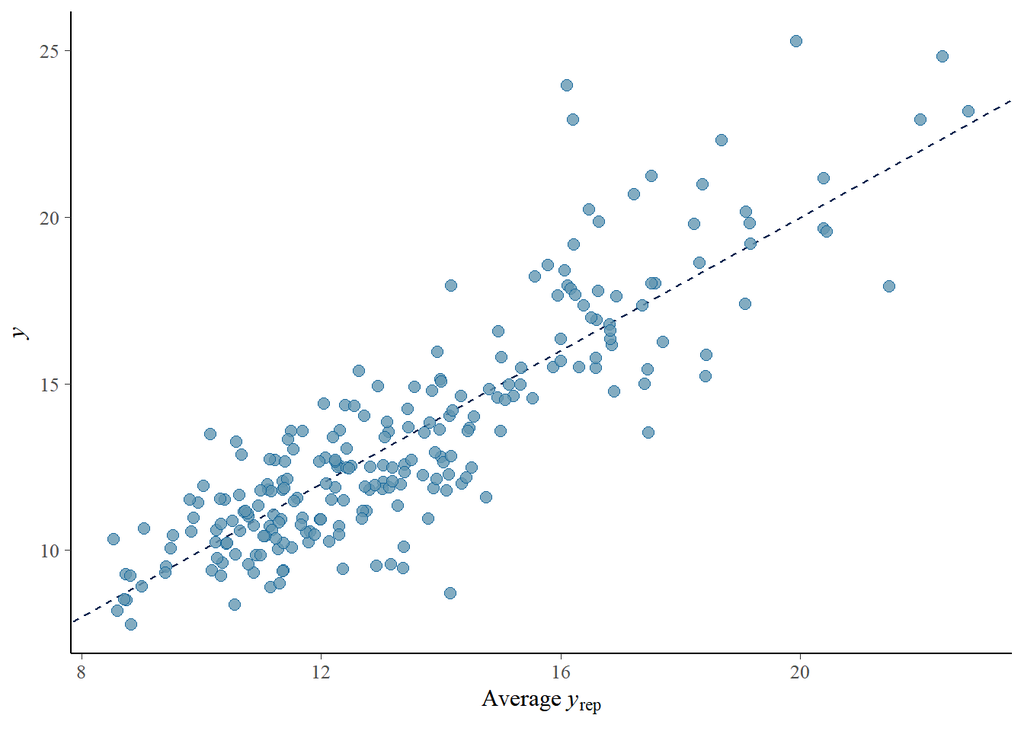

```r
pp_check(psa_dg_pl,type='scatter_avg', ndraws = 50)
```

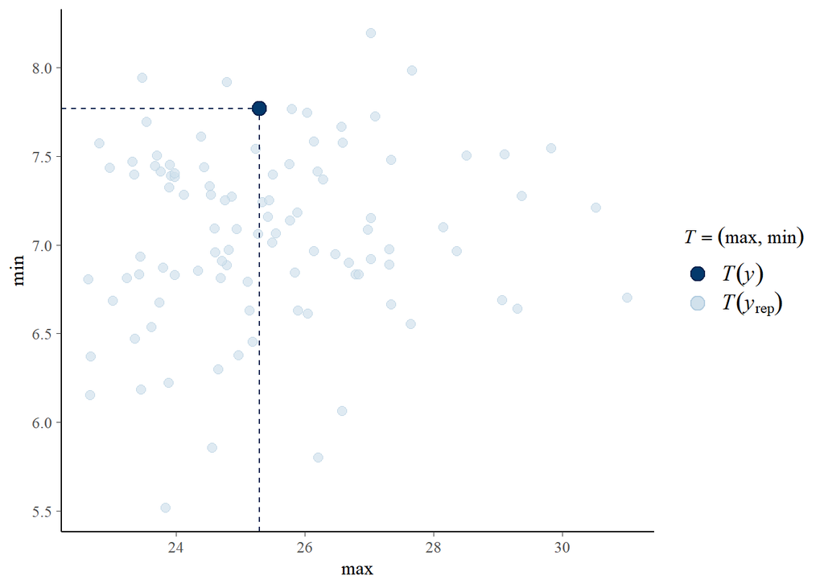

```r
pp_check(psa_dg_pl,type="stat_2d", stat = c("max", "min"),ndraws=100)
```

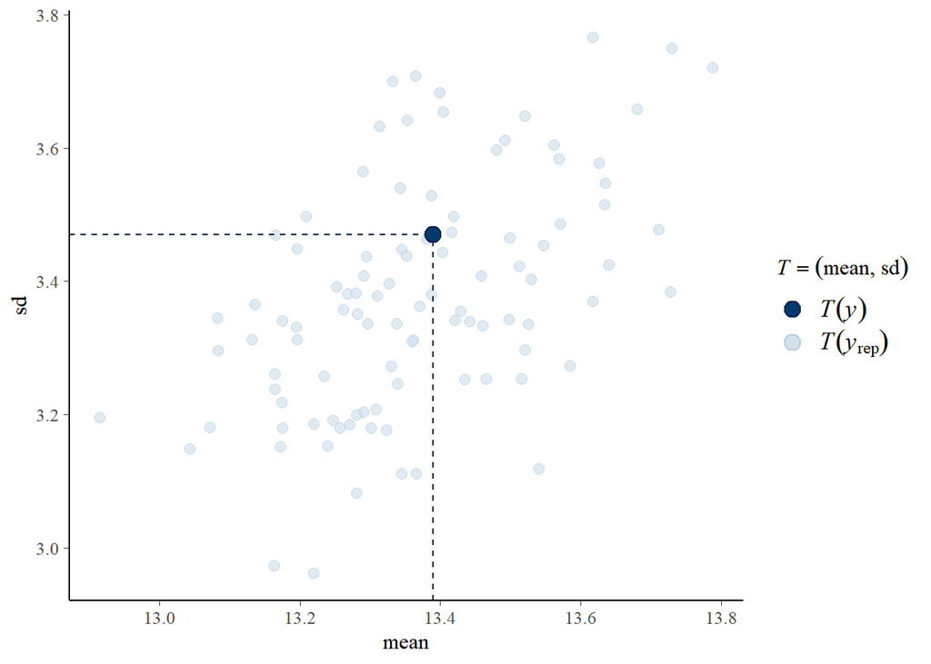

```r
pp_check(psa_dg_pl,type="stat_2d", stat = c("mean", "sd"),ndraws=100)
```

PPC seems mostly OK

### 6.1.4 Posterior draws extraction

```r
post_fix_dg_pl <- as.data.frame(psa_dg_pl, variable = c("b_Intercept","b_groupctrl.wt",
                                                        "b_groupeda.sca"), )
names(post_fix_dg_pl)[1]<-"sca_ctrl"

post_fix_dg_pl$wt_ctrl<-post_fix_dg_pl$sca_ctrl+post_fix_dg_pl$b_groupctrl.wt
post_fix_dg_pl$sca_eda<-post_fix_dg_pl$sca_ctrl+post_fix_dg_pl$b_groupeda.sca
summary(post_fix_dg_pl)
```

```
    sca_ctrl     b_groupctrl.wt     b_groupeda.sca        wt_ctrl
 Min.   :2.185   Min.   :-0.64125   Min.   :-0.63512   Min.   :2.228
 1st Qu.:2.484   1st Qu.: 0.03006   1st Qu.:-0.03839   1st Qu.:2.580
 Median :2.532   Median : 0.09235   Median : 0.02970   Median :2.626
 Mean   :2.532   Mean   : 0.09357   Mean   : 0.02864   Mean   :2.626
 3rd Qu.:2.579   3rd Qu.: 0.15839   3rd Qu.: 0.09638   3rd Qu.:2.671
 Max.   :3.185   Max.   : 0.70812   Max.   : 0.57747   Max.   :3.043
    sca_eda
 Min.   :2.205
 1st Qu.:2.515
 Median :2.560
 Mean   :2.561
 3rd Qu.:2.607
 Max.   :3.046
```

```r
groupquant_dg_pl<-sapply(post_fix_dg_pl[,c(4,1,5)],
                        function(p) quantile(p, probs = c(0.025,0.975,0.5)))
groupquant_dg_pl <- exp(groupquant_dg_pl)
```

# 7 Data and model visualization

In data visualization, individual points represent average per subject. Violin plot (area indicating data distribution) was, in contrast, constructed on the basis of individual data points (non-averaged)

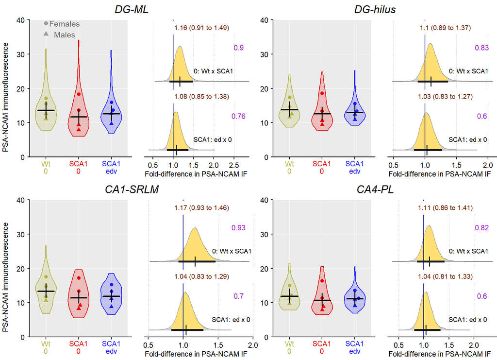

```r
suppressWarnings(suppressMessages( {

range<-c(0,40);scal<-range[2]-range[1]


mat <- matrix(c(15,1, 1, 2, 2,
                 5, 7, 8, 9,10,
                16, 3, 3, 4, 4,
                 6,11,12,13,14), byrow = TRUE, ncol = 5, nrow = 4)
layout(mat = mat, heights = c(0.04, 0.46, 0.04, 0.46),
       widths = c(0.02,rep(0.98/4, 4)) )

par(mar=c(0,0,0,0))
par(mgp=c(0,0,0))

plot(NULL, axes=FALSE,xlab="",ylab="",xlim=c(-1,1),ylim=c(-0.85,0.85))
text(0,-0.2,"DG-ML",cex=1.6,font=3,xpd=TRUE)

plot(NULL, axes=FALSE,xlab="",ylab="",xlim=c(-1,1),ylim=c(-0.85,0.85))
text(0,-0.2,"DG-hilus",cex=1.6,font=3,xpd=TRUE)

plot(NULL, axes=FALSE,xlab="",ylab="",xlim=c(-1,1),ylim=c(-0.85,0.85))
text(0,-0.2,"CA1-SRLM",cex=1.6,font=3,xpd=TRUE)

plot(NULL, axes=FALSE,xlab="",ylab="",xlim=c(-1,1),ylim=c(-0.85,0.85))
text(0,-0.2,"CA4-PL",cex=1.6,font=3,xpd=TRUE)



plot(NULL, axes=FALSE,xlab="",ylab="",xlim=c(-1,1),
     ylim=c(range[1],range[2]) )
text(0,range[1]+scal*0.5,"PSA-NCAM immunofluorescence", cex=1.15,srt=90)

plot(NULL, axes=FALSE,xlab="",ylab="",xlim=c(-1,1),
     ylim=c(range[1],range[2]) )
text(0,range[1]+scal*0.5,"PSA-NCAM immunofluorescence", cex=1.15,srt=90)

## DG-ML
par(mar=c(2.2,2,0,0))
par(mgp=c(2,0.6,0))


dg_ml$group<-factor(dg_ml$group,levels=c('ctrl.wt','ctrl.sca','eda.sca'))


xrange<-c(0.5,3.5);xscal=xrange[2]-xrange[1]
plot(NULL,xlim=c(xrange[1],xrange[2]),ylim=c(range[1],range[2]),xlab="",
     ylab="",las=1, axes=FALSE,cex.lab=1)

rect(xrange[1],range[2],xrange[2],range[1],col="grey92",border=NA)
x<-range[1]
repeat{
  lines(c(xrange[1],xrange[2]),c(x,x),col="white",lwd=0.7)
  x=x+10;if(x>range[2]){break}}

x<-1
repeat{
  lines(c(x,x),c(range[1],range[2]),col="white",lwd=0.7)
  x=x+1;if(x>4.5){break}}

vioplot(dg_ml$psa_ncam~dg_ml$group,col=colb[-2],at=c(1:4),add=T,
        border=cola[-2],axes=FALSE,drawRect=F,lwd=1,wex=0.8)

dg_ml_sum <- dg_ml %>% group_by(id, group, sex_num) %>% summarize(psa_ncam = mean(psa_ncam))


beeswarm(dg_ml_sum$psa_ncam~dg_ml_sum$group,col=cola[-2],at=c(1:3),
         add=T,pwpch=(16.5+dg_ml_sum$sex_num), cex=1.2 )

tp<-(groupquant_dgml[3,])
xx<-1;wid=0.25
repeat{
  lines(c(xx-wid,xx+wid),c(tp[xx],tp[xx]),lwd=2,col="black");
  lines(c(xx,xx),c(groupquant_dgml[1,xx],groupquant_dgml[2,xx]),lwd=1.7,col="black")
  xx<-xx+1
  if(xx>3){break}}

tckk=-0.02
axis(2,las=2,cex.axis=1.1,at=seq(range[1],range[2],by=10),
     labels=c(rep("",length(seq(range[1],range[2],by=10)))),pos=xrange[1],tck=tckk)
axis(2,las=2,cex.axis=1.1,at=seq(range[1],range[2],by=10),pos=xrange[1],tck=tckk)

axis(side=1,las=1,cex.axis=1.1,at=c(seq(1,4,by=1)),
     labels=c(rep("",length(seq(1,4,by=1)))),pos=range[1],tck=tckk)
lines(c(xrange[1],xrange[2]),c(range[1],range[1]))
text(c(1:3),c(rep(range[1]-0.046*scal,3)),xpd=T,cex=1.1,col=cola[-2],
     c("Wt", "SCA1", "SCA1"))
ypo<-c(range[1]-0.1*scal,range[1]-0.1*scal)
text(c(1:4),c(ypo[1],ypo[2],ypo[1],ypo[2]),xpd=T,cex=1.1,col=cola[-2],
     c("0", "0", "edv"))

ypos<-39;xpos=1
points(xpos,ypos,pch=16,cex=1.4,col=rgb(0.4,0.4,0.4,alpha=0.6))
text(xpos+0.19*xscal,ypos,"Females",col="grey40",cex=1.2)
points(xpos,ypos-0.08*scal,pch=17,cex=1.4,col=rgb(0.4,0.4,0.4,alpha=0.6))
text(xpos+0.19*xscal,ypos-0.08*scal,"Males",col="grey40",cex=1.2)

### probability distributions --------
par(mar=c(2.2,1,0,0))
dif<-data.frame(post_fix_dgml$b_groupeda.sca,
                post_fix_dgml$b_groupctrl.wt)
dif<-exp(dif)

yla<-"Fold-difference in PSA-NCAM IF"
tckk=-0.018
ste<-seq(0.5, 2.5,by=0.5)
mons_poste(dif,1)

zpos=seq(-0.05,1,1/2)
xx=1;ind=0.4;xpol<- 2

text(xpol,zpos[xx]+zpos[2]*ind,
     "SCA1: ed x 0 ",cex=1)
xx=xx+1

text(xpol,zpos[xx]+zpos[2]*ind,
     "0: Wt x SCA1",cex=1)




## DG-hilus
par(mar=c(2.2,2,0,0))
par(mgp=c(2,0.6,0))


dg_pl$group<-factor(dg_pl$group,levels=c('ctrl.wt','ctrl.sca','eda.sca'))


xrange<-c(0.5,3.5);xscal=xrange[2]-xrange[1]
plot(NULL,xlim=c(xrange[1],xrange[2]),ylim=c(range[1],range[2]),xlab="",
     ylab="",las=1, axes=FALSE,cex.lab=1)

rect(xrange[1],range[2],xrange[2],range[1],col="grey92",border=NA)
x<-range[1]
repeat{
  lines(c(xrange[1],xrange[2]),c(x,x),col="white",lwd=0.7)
  x=x+10;if(x>range[2]){break}}

x<-1
repeat{
  lines(c(x,x),c(range[1],range[2]),col="white",lwd=0.7)
  x=x+1;if(x>4.5){break}}

vioplot(dg_pl$psa_ncam~dg_pl$group,col=colb[-2],at=c(1:4),add=T,
        border=cola[-2],axes=FALSE,drawRect=F,lwd=1,wex=0.8)

dg_pl_sum <- dg_pl %>% group_by(id, group, sex_num) %>% summarize(psa_ncam = mean(psa_ncam))


beeswarm(dg_pl_sum$psa_ncam~dg_pl_sum$group,col=cola[-2],at=c(1:3),
         add=T,pwpch=(16.5+dg_pl_sum$sex_num), cex=1.2 )

tp<-(groupquant_dg_pl[3,])
xx<-1;wid=0.25
repeat{
  lines(c(xx-wid,xx+wid),c(tp[xx],tp[xx]),lwd=2,col="black");
  lines(c(xx,xx),c(groupquant_dg_pl[1,xx],groupquant_dg_pl[2,xx]),lwd=1.7,col="black")
  xx<-xx+1
  if(xx>3){break}}

tckk=-0.02
axis(2,las=2,cex.axis=1.1,at=seq(range[1],range[2],by=10),
     labels=c(rep("",length(seq(range[1],range[2],by=10)))),pos=xrange[1],tck=tckk)
axis(2,las=2,cex.axis=1.1,at=seq(range[1],range[2],by=10),pos=xrange[1],tck=tckk)

axis(side=1,las=1,cex.axis=1.1,at=c(seq(1,4,by=1)),
     labels=c(rep("",length(seq(1,4,by=1)))),pos=range[1],tck=tckk)
lines(c(xrange[1],xrange[2]),c(range[1],range[1]))
text(c(1:3),c(rep(range[1]-0.046*scal,3)),xpd=T,cex=1.1,col=cola[-2],
     c("Wt", "SCA1", "SCA1"))
ypo<-c(range[1]-0.1*scal,range[1]-0.1*scal)
text(c(1:4),c(ypo[1],ypo[2],ypo[1],ypo[2]),xpd=T,cex=1.1,col=cola[-2],
     c("0", "0", "edv"))

# ypos<-39;xpos=1
# points(xpos,ypos,pch=16,cex=1.4,col=rgb(0.4,0.4,0.4,alpha=0.6))
# text(xpos+0.19*xscal,ypos,"Females",col="grey40",cex=1.2)
# points(xpos,ypos-0.08*scal,pch=17,cex=1.4,col=rgb(0.4,0.4,0.4,alpha=0.6))
# text(xpos+0.19*xscal,ypos-0.08*scal,"Males",col="grey40",cex=1.2)

### probability distributions --------
par(mar=c(2.2,1,0,0))
dif<-data.frame(post_fix_dg_pl$b_groupeda.sca,
                post_fix_dg_pl$b_groupctrl.wt)
dif<-exp(dif)

yla<-"Fold-difference in PSA-NCAM IF"
tckk=-0.018
ste<-seq(0.5, 2.5,by=0.5)
mons_poste(dif,1)

zpos=seq(-0.05,1,1/2)
xx=1;ind=0.4;xpol<- 1.7

text(xpol,zpos[xx]+zpos[2]*ind,
     "SCA1: ed x 0 ",cex=1)
xx=xx+1

text(xpol,zpos[xx]+zpos[2]*ind,
     "0: Wt x SCA1",cex=1)





## CA-SRLM
par(mar=c(2.2,2,0,0))
par(mgp=c(2,0.6,0))


ca1_slm$group<-factor(ca1_slm$group,levels=c('ctrl.wt','ctrl.sca','eda.sca'))


xrange<-c(0.5,3.5);xscal=xrange[2]-xrange[1]
plot(NULL,xlim=c(xrange[1],xrange[2]),ylim=c(range[1],range[2]),xlab="",
     ylab="",las=1, axes=FALSE,cex.lab=1)

rect(xrange[1],range[2],xrange[2],range[1],col="grey92",border=NA)
x<-range[1]
repeat{
  lines(c(xrange[1],xrange[2]),c(x,x),col="white",lwd=0.7)
  x=x+10;if(x>range[2]){break}}

x<-1
repeat{
  lines(c(x,x),c(range[1],range[2]),col="white",lwd=0.7)
  x=x+1;if(x>4.5){break}}

vioplot(ca1_slm$psa_ncam~ca1_slm$group,col=colb[-2],at=c(1:4),add=T,
        border=cola[-2],axes=FALSE,drawRect=F,lwd=1,wex=0.8)

ca1_slm_sum <- ca1_slm %>% group_by(id, group, sex_num) %>% summarize(psa_ncam = mean(psa_ncam))


beeswarm(ca1_slm_sum$psa_ncam~ca1_slm_sum$group,col=cola[-2],at=c(1:3),
         add=T,pwpch=(16.5+ca1_slm_sum$sex_num), cex=1.2 )

tp<-(groupquant_ca1_slm[3,])
xx<-1;wid=0.25
repeat{
  lines(c(xx-wid,xx+wid),c(tp[xx],tp[xx]),lwd=2,col="black");
  lines(c(xx,xx),c(groupquant_ca1_slm[1,xx],groupquant_ca1_slm[2,xx]),lwd=1.7,col="black")
  xx<-xx+1
  if(xx>3){break}}

tckk=-0.02
axis(2,las=2,cex.axis=1.1,at=seq(range[1],range[2],by=10),
     labels=c(rep("",length(seq(range[1],range[2],by=10)))),pos=xrange[1],tck=tckk)
axis(2,las=2,cex.axis=1.1,at=seq(range[1],range[2],by=10),pos=xrange[1],tck=tckk)

axis(side=1,las=1,cex.axis=1.1,at=c(seq(1,4,by=1)),
     labels=c(rep("",length(seq(1,4,by=1)))),pos=range[1],tck=tckk)
lines(c(xrange[1],xrange[2]),c(range[1],range[1]))
text(c(1:3),c(rep(range[1]-0.046*scal,3)),xpd=T,cex=1.1,col=cola[-2],
     c("Wt", "SCA1", "SCA1"))
ypo<-c(range[1]-0.1*scal,range[1]-0.1*scal)
text(c(1:4),c(ypo[1],ypo[2],ypo[1],ypo[2]),xpd=T,cex=1.1,col=cola[-2],
     c("0", "0", "edv"))

# ypos<-39;xpos=1
# points(xpos,ypos,pch=16,cex=1.4,col=rgb(0.4,0.4,0.4,alpha=0.6))
# text(xpos+0.19*xscal,ypos,"Females",col="grey40",cex=1.2)
# points(xpos,ypos-0.08*scal,pch=17,cex=1.4,col=rgb(0.4,0.4,0.4,alpha=0.6))
# text(xpos+0.19*xscal,ypos-0.08*scal,"Males",col="grey40",cex=1.2)

### probability distributions --------
par(mar=c(2.2,1,0,0))
dif<-data.frame(post_fix_ca1_slm$b_groupeda.sca,
                post_fix_ca1_slm$b_groupctrl.wt)
dif<-exp(dif)

yla<-"Fold-difference in PSA-NCAM IF"
tckk=-0.018
ste<-seq(0.5, 2.5,by=0.5)
mons_poste(dif,1)

zpos=seq(-0.05,1,1/2)
xx=1;ind=0.4;xpol<- 1.7

text(xpol,zpos[xx]+zpos[2]*ind,
     "SCA1: ed x 0 ",cex=1)
xx=xx+1

text(xpol,zpos[xx]+zpos[2]*ind,
     "0: Wt x SCA1",cex=1)





## CA4 - pyramidal layer
par(mar=c(2.2,2,0,0))
par(mgp=c(2,0.6,0))


c4_pyr$group<-factor(c4_pyr$group,levels=c('ctrl.wt','ctrl.sca','eda.sca'))


xrange<-c(0.5,3.5);xscal=xrange[2]-xrange[1]
plot(NULL,xlim=c(xrange[1],xrange[2]),ylim=c(range[1],range[2]),xlab="",
     ylab="",las=1, axes=FALSE,cex.lab=1)

rect(xrange[1],range[2],xrange[2],range[1],col="grey92",border=NA)
x<-range[1]
repeat{
  lines(c(xrange[1],xrange[2]),c(x,x),col="white",lwd=0.7)
  x=x+10;if(x>range[2]){break}}

x<-1
repeat{
  lines(c(x,x),c(range[1],range[2]),col="white",lwd=0.7)
  x=x+1;if(x>4.5){break}}

vioplot(c4_pyr$psa_ncam~c4_pyr$group,col=colb[-2],at=c(1:4),add=T,
        border=cola[-2],axes=FALSE,drawRect=F,lwd=1,wex=0.8)

c4_pyr_sum <- c4_pyr %>% group_by(id, group, sex_num) %>% summarize(psa_ncam = mean(psa_ncam))


beeswarm(c4_pyr_sum$psa_ncam~c4_pyr_sum$group,col=cola[-2],at=c(1:3),
         add=T,pwpch=(16.5+c4_pyr_sum$sex_num), cex=1.2 )

tp<-(groupquant_c4_pyr[3,])
xx<-1;wid=0.25
repeat{
  lines(c(xx-wid,xx+wid),c(tp[xx],tp[xx]),lwd=2,col="black");
  lines(c(xx,xx),c(groupquant_c4_pyr[1,xx],groupquant_c4_pyr[2,xx]),lwd=1.7,col="black")
  xx<-xx+1
  if(xx>3){break}}

tckk=-0.02
axis(2,las=2,cex.axis=1.1,at=seq(range[1],range[2],by=10),
     labels=c(rep("",length(seq(range[1],range[2],by=10)))),pos=xrange[1],tck=tckk)
axis(2,las=2,cex.axis=1.1,at=seq(range[1],range[2],by=10),pos=xrange[1],tck=tckk)

axis(side=1,las=1,cex.axis=1.1,at=c(seq(1,4,by=1)),
     labels=c(rep("",length(seq(1,4,by=1)))),pos=range[1],tck=tckk)
lines(c(xrange[1],xrange[2]),c(range[1],range[1]))
text(c(1:3),c(rep(range[1]-0.046*scal,3)),xpd=T,cex=1.1,col=cola[-2],
     c("Wt", "SCA1", "SCA1"))
ypo<-c(range[1]-0.1*scal,range[1]-0.1*scal)
text(c(1:4),c(ypo[1],ypo[2],ypo[1],ypo[2]),xpd=T,cex=1.1,col=cola[-2],
     c("0", "0", "edv"))

# ypos<-39;xpos=1
# points(xpos,ypos,pch=16,cex=1.4,col=rgb(0.4,0.4,0.4,alpha=0.6))
# text(xpos+0.19*xscal,ypos,"Females",col="grey40",cex=1.2)
# points(xpos,ypos-0.08*scal,pch=17,cex=1.4,col=rgb(0.4,0.4,0.4,alpha=0.6))
# text(xpos+0.19*xscal,ypos-0.08*scal,"Males",col="grey40",cex=1.2)

### probability distributions --------
par(mar=c(2.2,1,0,0))
dif<-data.frame(post_fix_c4_pyr$b_groupeda.sca,
                post_fix_c4_pyr$b_groupctrl.wt)
dif<-exp(dif)

yla<-"Fold-difference in PSA-NCAM IF"
tckk=-0.018
ste<-seq(0.5, 2.5,by=0.5)
mons_poste(dif,1)

zpos=seq(-0.05,1,1/2)
xx=1;ind=0.4;xpol<- 1.9

text(xpol,zpos[xx]+zpos[2]*ind,
     "SCA1: ed x 0 ",cex=1)
xx=xx+1

text(xpol,zpos[xx]+zpos[2]*ind,
     "0: Wt x SCA1",cex=1)


} ))
```